# global_climate_change

Ryan Whalen

### Changes in Modern Temperatures

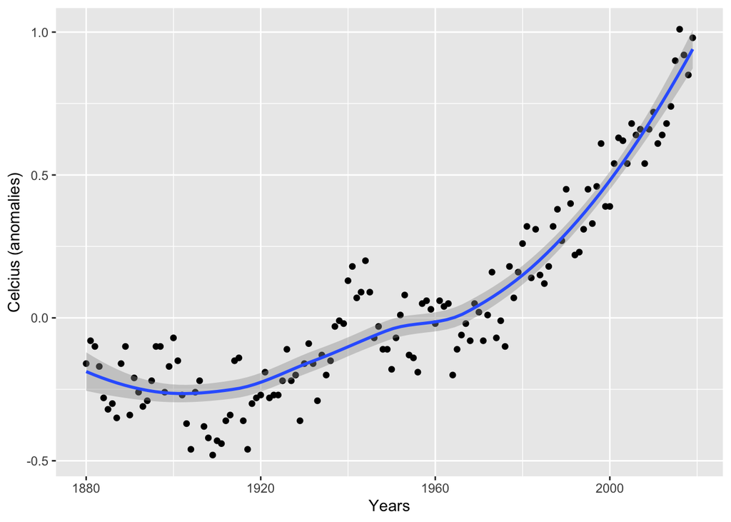

```
##
## Call:
## lm(formula = annual_temp ~ year, data = global_temp_annual)
##
## Residuals:
##      Min       1Q   Median       3Q      Max
## -0.35065 -0.13436 -0.02465  0.11823  0.47305
##
## Coefficients:
##               Estimate Std. Error t value Pr(>|t|)
## (Intercept) -14.439711   0.717498  -20.12   <2e-16 ***
## year          0.007429   0.000368   20.19   <2e-16 ***
## ---
## Signif. codes:  0 '***' 0.001 '**' 0.01 '*' 0.05 '.' 0.1 ' ' 1
##
## Residual standard error: 0.176 on 138 degrees of freedom
## Multiple R-squared:  0.7471, Adjusted R-squared:  0.7452
## F-statistic: 407.6 on 1 and 138 DF,  p-value: < 2.2e-16
```

#### Changes in Modern Temperatures (Post 1950)

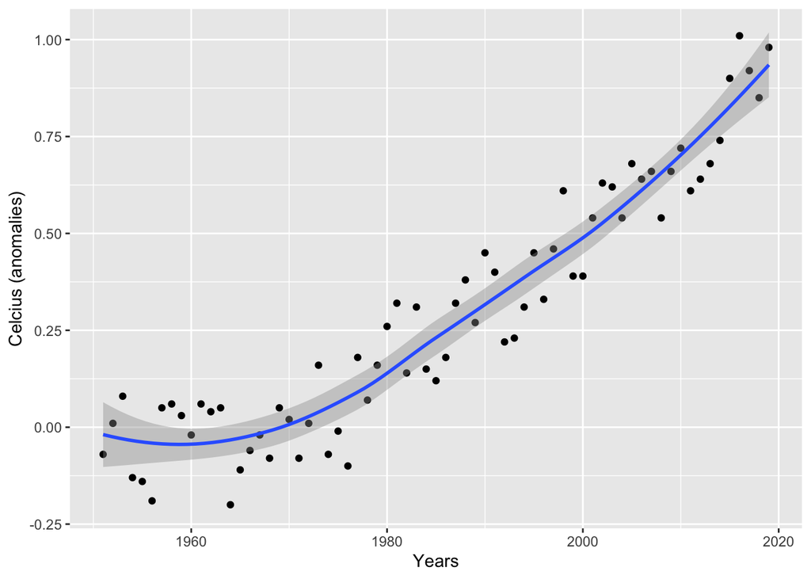

```
##
## Call:
## lm(formula = annual_temp ~ year, data = post_1950)
##
## Residuals:
##      Min       1Q   Median       3Q      Max
## -0.25605 -0.10251  0.01148  0.08581  0.26589
##
## Coefficients:
##               Estimate Std. Error t value Pr(>|t|)
## (Intercept) -2.922e+01  1.414e+00  -20.66   <2e-16 ***
## year         1.487e-02  7.124e-04   20.87   <2e-16 ***
## ---
## Signif. codes:  0 '***' 0.001 '**' 0.01 '*' 0.05 '.' 0.1 ' ' 1
##
## Residual standard error: 0.1179 on 67 degrees of freedom
## Multiple R-squared:  0.8667, Adjusted R-squared:  0.8647
## F-statistic: 435.6 on 1 and 67 DF,  p-value: < 2.2e-16
```

### Changes in Modern Atmospheric CO2

```
##
## Call:
## lm(formula = mean ~ year, data = co2_data)
##
## Residuals:
##    Min     1Q Median     3Q    Max
## -4.555 -2.782 -1.448  2.167  8.694
##
## Coefficients:
##               Estimate Std. Error t value Pr(>|t|)
## (Intercept) -2.788e+03  5.307e+01  -52.54   <2e-16 ***
## year         1.580e+00  2.668e-02   59.24   <2e-16 ***
## ---
## Signif. codes:  0 '***' 0.001 '**' 0.01 '*' 0.05 '.' 0.1 ' ' 1
##
## Residual standard error: 3.669 on 59 degrees of freedom
## Multiple R-squared:  0.9835, Adjusted R-squared:  0.9832
## F-statistic:  3509 on 1 and 59 DF,  p-value: < 2.2e-16
```

#### Relationship between modern temperatures and atmospheric CO2

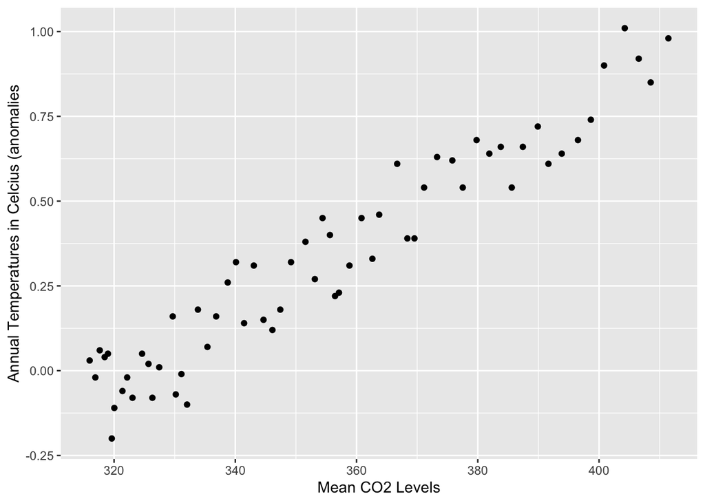

```
##
## Call:
## lm(formula = annual_temp ~ mean, data = temp_co2_data)
##
## Residuals:
##       Min        1Q    Median        3Q       Max
## -0.185535 -0.069815  0.002107  0.075427  0.156574
##
## Coefficients:
##               Estimate Std. Error t value Pr(>|t|)
## (Intercept) -3.4459121  0.1465651  -23.51   <2e-16 ***
## mean         0.0106356  0.0004112   25.86   <2e-16 ***
## ---
## Signif. codes:  0 '***' 0.001 '**' 0.01 '*' 0.05 '.' 0.1 ' ' 1
##
## Residual standard error: 0.09011 on 59 degrees of freedom
## Multiple R-squared:  0.919,  Adjusted R-squared:  0.9176
## F-statistic:   669 on 1 and 59 DF,  p-value: < 2.2e-16
```

### Pre-historic Temperature Data

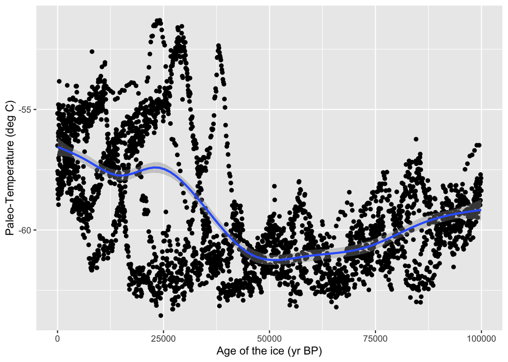

```
##
## Call:
## lm(formula = vostok_temp_data$`Paleo-Temperature (deg C)` ~ vostok_temp_data$`Age of the ice (yr BP)`,
##     data = vostok_temp_data)
##
## Residuals:
##     Min      1Q  Median      3Q     Max
## -5.2562 -1.9046 -0.2061  1.8161  6.9846
##
## Coefficients:
##                                             Estimate Std. Error t value
## (Intercept)                               -5.734e+01  7.384e-02  -776.6
## vostok_temp_data$`Age of the ice (yr BP)` -3.900e-05  1.403e-06   -27.8
##                                           Pr(>|t|)
## (Intercept)                                 <2e-16 ***
## vostok_temp_data$`Age of the ice (yr BP)`   <2e-16 ***
## ---
## Signif. codes:  0 '***' 0.001 '**' 0.01 '*' 0.05 '.' 0.1 ' ' 1
##
## Residual standard error: 2.407 on 3309 degrees of freedom
## Multiple R-squared:  0.1894, Adjusted R-squared:  0.1891
## F-statistic:   773 on 1 and 3309 DF,  p-value: < 2.2e-16
```

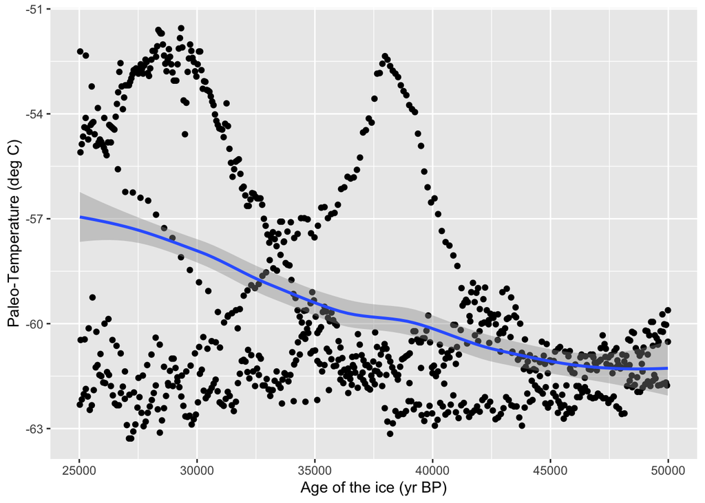

```
##
## Call:
## lm(formula = vostok_fast_change$`Paleo-Temperature (deg C)` ~
##     vostok_fast_change$`Age of the ice (yr BP)`, data = vostok_fast_change)
##
## Residuals:
##     Min      1Q  Median      3Q     Max
## -5.8579 -2.0668 -0.3289  1.7112  7.2910
##
## Coefficients:
##                                               Estimate Std. Error t value
## (Intercept)                                 -5.190e+01  5.208e-01  -99.65
## vostok_fast_change$`Age of the ice (yr BP)` -2.039e-04  1.397e-05  -14.59
##                                             Pr(>|t|)
## (Intercept)                                   <2e-16 ***
## vostok_fast_change$`Age of the ice (yr BP)`   <2e-16 ***
## ---
## Signif. codes:  0 '***' 0.001 '**' 0.01 '*' 0.05 '.' 0.1 ' ' 1
##
## Residual standard error: 2.892 on 813 degrees of freedom
## Multiple R-squared:  0.2076, Adjusted R-squared:  0.2066
## F-statistic:   213 on 1 and 813 DF,  p-value: < 2.2e-16
```

### Pre-historic CO2 Data

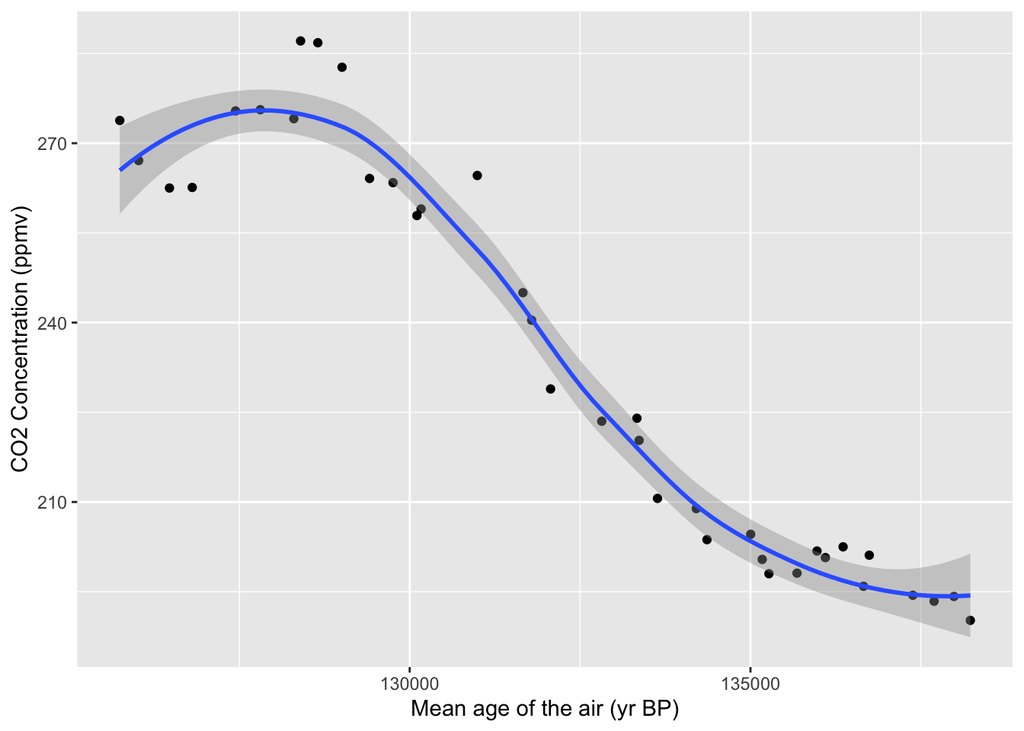

```
##
## Call:
## lm(formula = vostok_co2_focus_data$`CO2 Concentration (ppmv)` ~
##     vostok_co2_focus_data$`Mean age of the air (yr BP)`, data = vostok_co2_focus_data)
##
## Residuals:
##     Min      1Q  Median      3Q     Max
## -19.852  -7.464   1.137   5.896  22.602
##
## Coefficients:
##                                                       Estimate Std. Error
## (Intercept)                                          1.337e+03  6.423e+01
## vostok_co2_focus_data$`Mean age of the air (yr BP)` -8.339e-03  4.851e-04
##                                                     t value Pr(>|t|)
## (Intercept)                                           20.82   <2e-16 ***
## vostok_co2_focus_data$`Mean age of the air (yr BP)`  -17.19   <2e-16 ***
## ---
## Signif. codes:  0 '***' 0.001 '**' 0.01 '*' 0.05 '.' 0.1 ' ' 1
##
## Residual standard error: 11.12 on 35 degrees of freedom
## Multiple R-squared:  0.8941, Adjusted R-squared:  0.8911
## F-statistic: 295.5 on 1 and 35 DF,  p-value: < 2.2e-16
```

#### Comparison of modern and pre-historic rate of changes in CO2

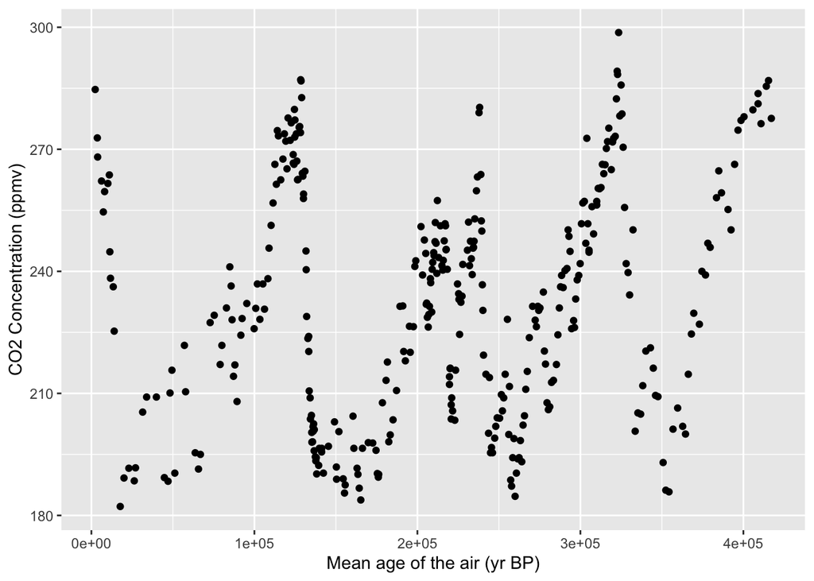

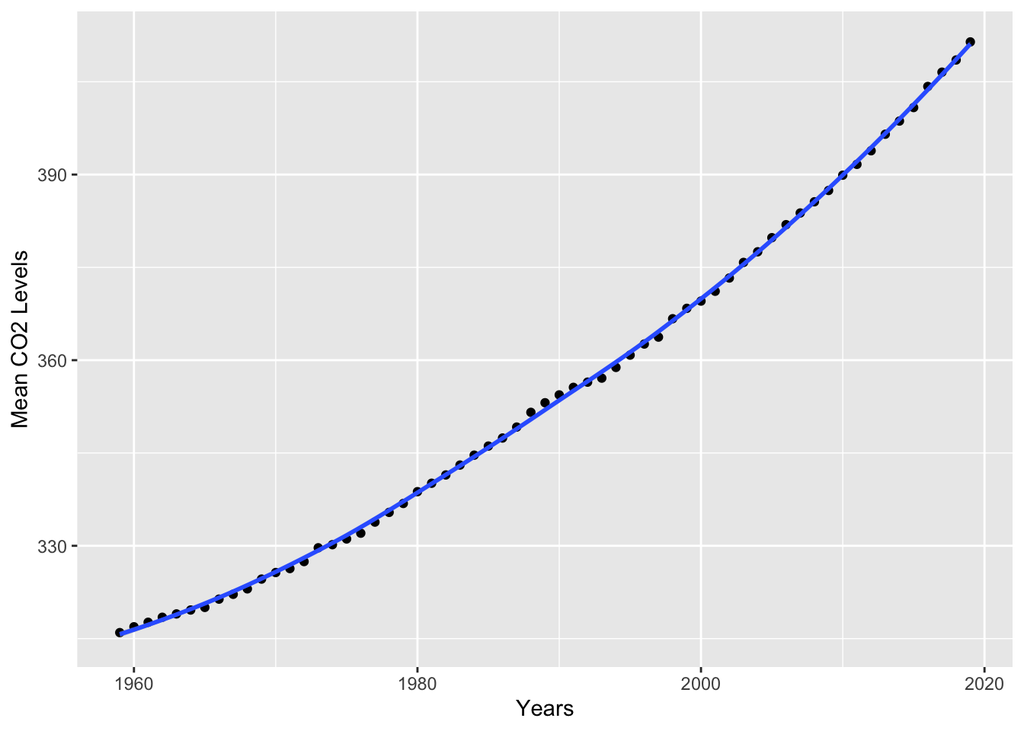

### Hypothesis **Question 11:** How do current (i.e., since 1950) changes in atmospheric CO2 concentration and average global temperature compare to pre-historic (i.e., in the past hundreds of thousands of years) changes in these variables?

**Answer 11:** Current changes in atmospheric CO2 and temperature are increasing at a steady rate while the CO2 atmospheric concentration and temperature changes in the pre-historic era fluctuated greatly and weren’t steadily increasing **Question 12:** What does this suggest about whether recent changes in temperature are due to natural or anthropogenic (human) factors?

**Answer 12:** This highly suggests that the recent changes in temperature are due to anthropogenic factors **Question 13:** Is plausible that recent increase in atmospheric carbon dioxide is a result of natural fluctuations and not human-induced?

**Answer 13:** It could be natural fluctuations but it likely isn’t. The CO2 naturally flucated in pre-historic times but never really went above 300ppmv of CO2 while in todays world we have over 400ppmv of atmospheric CO2 ## Citation

This module was initially developed as an Excel-based exercise by:

O’Reilly, C.M., D.C. Richardson, and R.D. Gougis. 15 March 2017. Project EDDIE: Climate Change. Project EDDIE Module 8, Version 1. http://cemast.illinoisstate.edu/data-for-students/modules/climate-change.shtml. Module development was supported by NSF DEB 1245707